# Los Angeles Real Estate Statistics

## Libraries

```r
library(tidyverse)
library(gridExtra)
library(glmnet)
```

## Data Load

```r
df <- read.csv('data/mls_data/inglewood_mls_data.csv', header = T, na.strings = c('', 'NA'))
```

## Data Setup

```r
knitr::kable(head(df))
```

| X. | STREET.. | STREET.NAME | CITY | YEAR.BUILT | BED..BATH | LIVING.SPACE | LOT.SIZE | ORIGINAL.LIST…. | CHANGE..CLOSE…. | ON.MARKET.DATE | CONTRACT..CLOSE.DATE | DAYS.ON.MARKET | STATUS | X | X.1 | X.2 | X.3 | X.4 | X.5 | X.6 |
| --- | --- | --- | --- | --- | --- | --- | --- | --- | --- | --- | --- | --- | --- | --- | --- | --- | --- | --- | --- | --- |
| 1 | 3501 W | 80th ST | Inglewood | 1939 | 3/2,0,0,0 | 1859 | 5902 | $765,000.00 | NA | 2/24/2020 | NA | 30 | Active | NA | NA | NA | NA | NA | NA | NA |
| 2 | 8116 | Maitland AVE | Inglewood | 1936 | 3/2,0,0,0 | 1723 | 5504 | $799,000.00 | NA | 3/11/2020 | NA | 15 | Active | NA | NA | NA | NA | NA | NA | NA |
| 3 | 8921 | Crenshaw BLVD | Inglewood | 1946 | 3/2,0,0,0 | 1777 | 6552 | $840,000.00 | NA | 1/6/2020 | NA | 80 | Active | NA | NA | NA | NA | NA | NA | NA |
| 4 | 9105 S | Calvin WAY | Inglewood | 2005 | 4/3,0,0,0 | 2597 | 3263 | $849,900.00 | NA | 3/9/2020 | NA | 17 | Active | NA | NA | NA | NA | NA | NA | NA |
| 5 | 920 E | FAIRVIEW | Inglewood | 2019 | 4/4,0,0,0 | 2218 | 5466 | $1,350,000.00 | NA | 2/28/2020 | NA | 27 | Active | NA | NA | NA | NA | NA | NA | NA |
| 6 | 611 | Magnolia AVE | Inglewood | 1925 | 3/2,0,0,0 | 1100 | 4967 | $749,000.00 | $699,900.00 | 3/10/2020 | NA | 16 | Active | NA | NA | NA | NA | NA | NA | NA |

Rename columns and remove empty columns.

```r
df <-
  df %>%
  select(-c('X', 'X.1', 'X.2', 'X.3', 'X.4', 'X.5', 'X.6')) %>%
  rename(
    id = X.,
    street_num = STREET..,
    street_name = STREET.NAME,
    city = CITY,
    built_yr = YEAR.BUILT,
    bed_bath = BED..BATH,
    sq_ft = LIVING.SPACE,
    lot_size = LOT.SIZE,
    org_list = ORIGINAL.LIST....,
    new_list = CHANGE..CLOSE....,
    list_date = ON.MARKET.DATE,
    close_date = CONTRACT..CLOSE.DATE,
    days_listed = DAYS.ON.MARKET,
    status = STATUS
  )

knitr::kable(head(df))
```

| id | street_num | street_name | city | built_yr | bed_bath | sq_ft | lot_size | org_list | new_list | list_date | close_date | days_listed | status |
| --- | --- | --- | --- | --- | --- | --- | --- | --- | --- | --- | --- | --- | --- |
| 1 | 3501 W | 80th ST | Inglewood | 1939 | 3/2,0,0,0 | 1859 | 5902 | $765,000.00 | NA | 2/24/2020 | NA | 30 | Active |
| 2 | 8116 | Maitland AVE | Inglewood | 1936 | 3/2,0,0,0 | 1723 | 5504 | $799,000.00 | NA | 3/11/2020 | NA | 15 | Active |
| 3 | 8921 | Crenshaw BLVD | Inglewood | 1946 | 3/2,0,0,0 | 1777 | 6552 | $840,000.00 | NA | 1/6/2020 | NA | 80 | Active |
| 4 | 9105 S | Calvin WAY | Inglewood | 2005 | 4/3,0,0,0 | 2597 | 3263 | $849,900.00 | NA | 3/9/2020 | NA | 17 | Active |
| 5 | 920 E | FAIRVIEW | Inglewood | 2019 | 4/4,0,0,0 | 2218 | 5466 | $1,350,000.00 | NA | 2/28/2020 | NA | 27 | Active |
| 6 | 611 | Magnolia AVE | Inglewood | 1925 | 3/2,0,0,0 | 1100 | 4967 | $749,000.00 | $699,900.00 | 3/10/2020 | NA | 16 | Active |

Transform data into manageable formats.

```r
# Convert bed/bath char values into separate integers
df <-
  df %>%
  mutate(street_address = paste(df$street_num, df$street_name)) %>%
  separate(bed_bath,
           into = c('bed', 'bath'),
           sep = '/') %>%
  separate(
    bath,
    into = c('full', '3q', 'half', 'q'),
    sep = ',',
    convert = T
  ) %>%
  mutate(bath = full + `3q` * .75 + half * .5 + q * .25) %>%
  select(-c('full', '3q', 'half', 'q'))

# Remove '$' from prices
df$org_list <- sapply(df$org_list, function(x) {
  gsub('\\$|,', '', x)
})
df$new_list <- sapply(df$new_list, function(x) {
  gsub('\\$|,', '', x)
})

# Convert variables to numeric type
df$org_list <- as.numeric(df$org_list)
df$new_list <- as.numeric(df$new_list)
df$bed <- as.numeric(df$bed)

# Convert dates into date type
df$list_date <- as.Date(df$list_date, format = '%m/%d/%Y')
df$close_date <- as.Date(df$close_date, format = '%m/%d/%Y')

knitr::kable(head(df))
```

| id | street_num | street_name | city | built_yr | bed | sq_ft | lot_size | org_list | new_list | list_date | close_date | days_listed | status | street_address | bath |
| --- | --- | --- | --- | --- | --- | --- | --- | --- | --- | --- | --- | --- | --- | --- | --- |
| 1 | 3501 W | 80th ST | Inglewood | 1939 | 3 | 1859 | 5902 | 765000 | NA | 2020-02-24 | NA | 30 | Active | 3501 W 80th ST | 2 |
| 2 | 8116 | Maitland AVE | Inglewood | 1936 | 3 | 1723 | 5504 | 799000 | NA | 2020-03-11 | NA | 15 | Active | 8116 Maitland AVE | 2 |
| 3 | 8921 | Crenshaw BLVD | Inglewood | 1946 | 3 | 1777 | 6552 | 840000 | NA | 2020-01-06 | NA | 80 | Active | 8921 Crenshaw BLVD | 2 |
| 4 | 9105 S | Calvin WAY | Inglewood | 2005 | 4 | 2597 | 3263 | 849900 | NA | 2020-03-09 | NA | 17 | Active | 9105 S Calvin WAY | 3 |
| 5 | 920 E | FAIRVIEW | Inglewood | 2019 | 4 | 2218 | 5466 | 1350000 | NA | 2020-02-28 | NA | 27 | Active | 920 E FAIRVIEW | 4 |
| 6 | 611 | Magnolia AVE | Inglewood | 1925 | 3 | 1100 | 4967 | 749000 | 699900 | 2020-03-10 | NA | 16 | Active | 611 Magnolia AVE | 2 |

Do houses appear more than once in the dataset?

```r
nrow(df) == nrow(unique(df$street_address))
```

```
## logical(0)
```

## Data Exploration and Feature Engineering

```r
df_closed <-
  df %>%
  filter(status == 'Closed') %>%
  mutate(new_list_per_sq_ft = new_list / sq_ft)

summary(df_closed)
```

```
##        id        street_num      street_name         city
##  Min.   : 31   3208 W :  3   78TH PL   :  5   Inglewood:137
##  1st Qu.: 65   10318  :  2   108th ST  :  3
##  Median : 99   10502 S:  2   111th ST  :  3
##  Mean   : 99   2300 W :  2   112th ST  :  3
##  3rd Qu.:133   2319 W :  2   2ND AVE   :  3
##  Max.   :167   3502 W :  2   3RD AVE   :  3
##                (Other):124   (Other)   :117
##     built_yr         bed            sq_ft         lot_size
##  Min.   :1921   Min.   :3.000   Min.   : 975   Min.   :    0
##  1st Qu.:1931   1st Qu.:3.000   1st Qu.:1341   1st Qu.: 5401
##  Median :1941   Median :3.000   Median :1561   Median : 6007
##  Mean   :1945   Mean   :3.285   Mean   :1606   Mean   : 6099
##  3rd Qu.:1953   3rd Qu.:4.000   3rd Qu.:1785   3rd Qu.: 6714
##  Max.   :2012   Max.   :5.000   Max.   :3191   Max.   :11404
##                                                NA's   :3
##     org_list          new_list         list_date
##  Min.   : 408000   Min.   : 408500   Min.   :2018-09-12
##  1st Qu.: 609750   1st Qu.: 610000   1st Qu.:2019-03-08
##  Median : 675000   Median : 660000   Median :2019-06-18
##  Mean   : 685026   Mean   : 682392   Mean   :2019-06-19
##  3rd Qu.: 729999   3rd Qu.: 749000   3rd Qu.:2019-09-05
##  Max.   :1549000   Max.   :1525000   Max.   :2020-03-13
##  NA's   :1
##    close_date          days_listed                       status
##  Min.   :2019-03-22   Min.   :  0.00   Active               :  0
##  1st Qu.:2019-06-12   1st Qu.: 10.00   Active Under Contract:  0
##  Median :2019-08-30   Median : 22.00   Closed               :137
##  Mean   :2019-09-11   Mean   : 43.99   Pending              :  0
##  3rd Qu.:2019-12-12   3rd Qu.: 64.00
##  Max.   :2020-03-17   Max.   :277.00
##
##  street_address          bath      new_list_per_sq_ft
##  Length:137         Min.   :1.50   Min.   :272.7
##  Class :character   1st Qu.:2.00   1st Qu.:376.2
##  Mode  :character   Median :2.00   Median :420.3
##                     Mean   :2.15   Mean   :438.5
##                     3rd Qu.:2.00   3rd Qu.:491.7
##                     Max.   :4.00   Max.   :706.2
##
```

Remove $1.5mil outlier

```r
df_closed <-
  df_closed %>%
  filter(new_list < 1500000 & city == 'Inglewood')
```

List price vs close date, year built, bedrooms, bathrooms, square feet

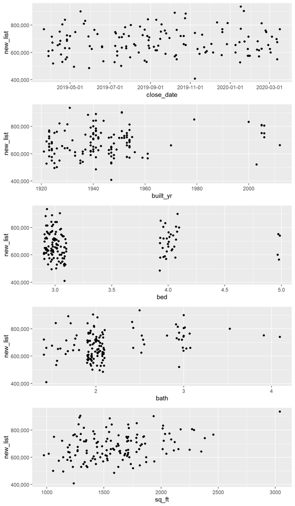

```r
close_date <-
  ggplot(df_closed) +
  geom_point(aes(close_date, new_list)) +
  scale_x_date(date_breaks = '2 months', date_minor_breaks = '1 months') +
  scale_y_continuous(labels = scales::comma)

built_yr <-
  ggplot(df_closed) +
  geom_point(aes(built_yr, new_list)) +
  scale_y_continuous(labels = scales::comma)

bedrooms <-
  ggplot(df_closed) +
  geom_jitter(aes(bed, new_list), width = 0.1) +
  scale_y_continuous(labels = scales::comma)

bathrooms <-
  ggplot(df_closed) +
  geom_jitter(aes(bath, new_list), width = 0.1) +
  scale_y_continuous(labels = scales::comma)

sq_ft <-
  ggplot(df_closed) +
  geom_point(aes(sq_ft, new_list)) +
  scale_y_continuous(labels = scales::comma)

grid.arrange(close_date, built_yr, bedrooms, bathrooms, sq_ft, nrow = 5)
```

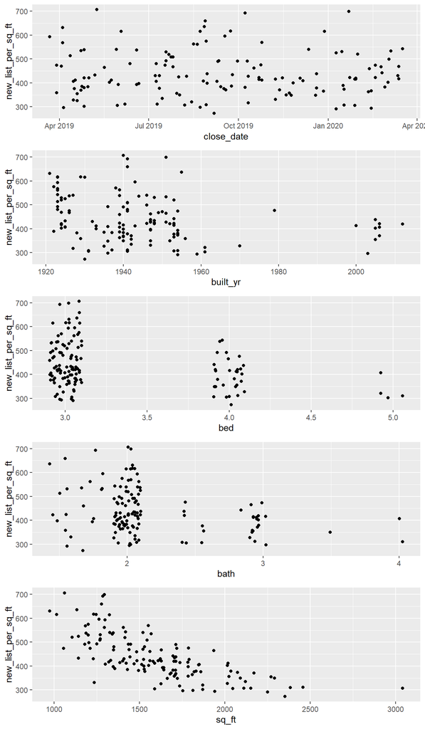

```r
close_date <-
  ggplot(df_closed) +
  geom_point(aes(close_date, new_list_per_sq_ft))

built_yr <-
  ggplot(df_closed) +
  geom_point(aes(built_yr, new_list_per_sq_ft))

bedrooms <-
  ggplot(df_closed) +
  geom_jitter(aes(bed, new_list_per_sq_ft), width = 0.1)

bathrooms <-
  ggplot(df_closed) +
  geom_jitter(aes(bath, new_list_per_sq_ft), width = 0.1)

sq_ft <-
  ggplot(df_closed) +
  geom_point(aes(sq_ft, new_list_per_sq_ft))

grid.arrange(close_date, built_yr, bedrooms, bathrooms, sq_ft, nrow = 5)
```

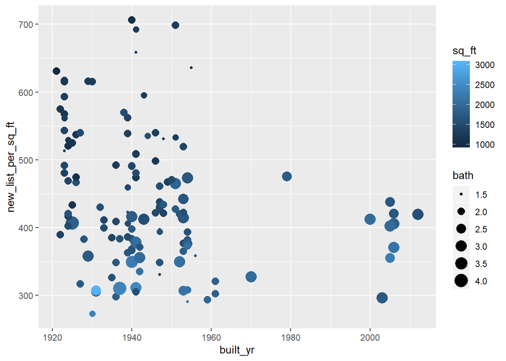

```r
ggplot() + geom_point(df_closed, mapping = aes(x = built_yr, y = new_list_per_sq_ft, size = bath, color = sq_ft))
```

Original list price vs new list price

```r
df_closed <-
  df_closed %>%
  mutate(new_list_diff = new_list - org_list,
         new_list_diff_perc = ((new_list - org_list) / org_list) * 100)

summary(select(df_closed, new_list_diff, new_list_diff_perc))
```

```
##  new_list_diff     new_list_diff_perc
##  Min.   :-122400   Min.   :-18.83367
##  1st Qu.: -20278   1st Qu.: -3.51682
##  Median :      0   Median :  0.00000
##  Mean   :  -1495   Mean   : -0.03499
##  3rd Qu.:  25100   3rd Qu.:  3.72012
##  Max.   : 106000   Max.   : 20.50114
##  NA's   :1         NA's   :1
```

On average, properties are selling fairly close to their original list price, but it’s fairly common to see homes close at +/- 3.6% from original list price. Would be interesting to do further analysis to see what predicts whether homes will close significantly below or above list price.

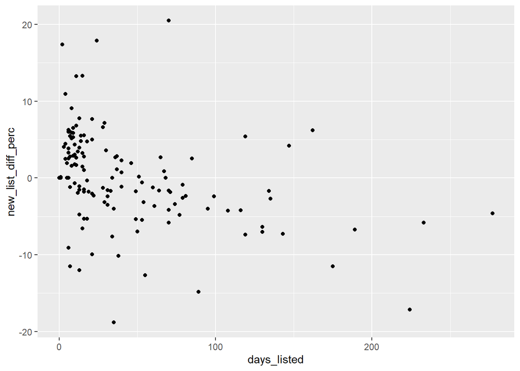

```r
ggplot(df_closed) +
  geom_point(aes(days_listed, new_list_diff_perc))
```

## Regression

```r
# Select variables
df_closed_reg <-
  df_closed %>%
  select(built_yr, bed, bath, sq_ft, lot_size, new_list)

# Filter out rows with missing values
df_closed_reg <-
  df_closed_reg %>%
  filter(rowSums(is.na(df_closed_reg)) == 0)

X <-
  df_closed_reg %>%
  select(built_yr, bed, bath, sq_ft, lot_size)

y <- df_closed_reg %>%
  select(new_list)

X <- data.matrix(X)
y <- data.matrix(y)

set.seed(123)

cvmodel = cv.glmnet(X, y)
coef(cvmodel)
```

```
## 6 x 1 sparse Matrix of class "dgCMatrix"
##                        1
## (Intercept) 621508.76232
## built_yr         .
## bed              .
## bath          8976.42766
## sq_ft           22.63121
## lot_size         .
```

Simplified rough interpretation of the above results:

- On average, each additional bathroom in a property raises the price $9k
- On average, each square foot raises the price of a property $23

This linear model doesn’t reflect the reality where there are diminishing marginal returns for additional bathrooms and square footage when the number of bathrooms and square footage is already high.